# Projeto de Análise de Dados em R - Bloco 2

Neste bloco vamos trabalhar diretamente com a base de dados, tratando os dados para análise e explorando as distribuições com estatística descritiva e gráficos. Primeiro importe a base de dados para o ambiente.

# Tratamento de Dados

### Seleção

```r
# selecionar colunas no banco por nome
database <- Latinobarometro_2015_Eng[, c("P21ST.C", "P32N", "P63NJ.G", "S23",
    "S12", "S6", "S24.K", "S18")]

# renomear colunas
colnames(database) <- c("participa_protestos", "interesse_político", "violencia_policial",
    "raca", "genero", "classe_social", "esgotamento", "escolaridade")
```

### Casos Faltantes

Um dos problemas na análise de dados é a existência de casos faltantes (**missing cases**), sobretudo na execução de modelos estatísticos. Uma variável importante num banco de dados pode conter informações que em alguns casos não foram preenchidas e na retirada desses casos pode haver uma perda sistemática de informação.

```r
# instalar e carregar pacote Amelia
install.packages("Amelia")
library(Amelia)
```

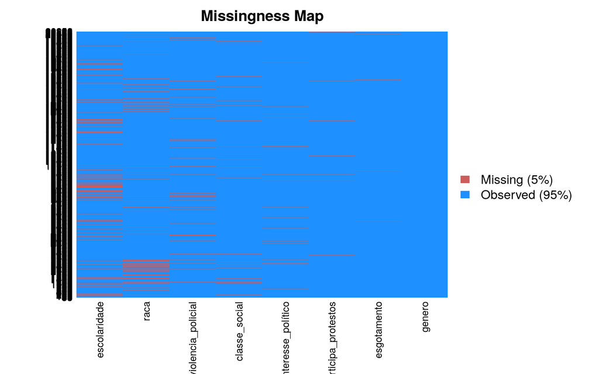

```r
# visualizar casos faltantes no banco
missmap(database)
```

```r
# contabilizar
is.na(database)
```

[output not shown]

```r
sum(is.na(database))
```

```
[1] 7387
```

```r
# porcentagem de faltantes do total
sum(is.na(database))/dim(database)[1]
```

```
[1] 0.3647901
```

```r
# selecionar casos completos
databaseClean <- database[complete.cases(database), ]
```

# Estatística Descritiva

A estatística descritiva é uma ferramenta para identificar a distribuição dos dados e por muitas vezes já traz informações utéis e que auxiliam na análise. Vamos desenvolver os comandos para frequência, mínimo, máximo, média, mediana, desvio-padrão, entre outros.

```r
# frequencia de contagem (variaveis nominais e categoricas)
table(database$participa_protestos)
```

```
    1     2     3
  905  3266 15738
```

```r
table(database$interesse_político)
```

```
    1     2     3     4     5
11106  6085   574   816  1184
```

```r
# instalar e carregar pacote dplyr
install.packages("dplyr")
library(dplyr)
```

```r
# construir um data.frame e transformar em porcentagem
violenciaData <- data.frame(table(database$violencia_policial))
violenciaData <- mutate(violenciaData, porcentagem = (Freq/sum(Freq)) * 100)
violenciaData$porcentagem <- round(violenciaData$porcentagem, 2)
```

```r
# minimo, primeiro quartil, mediana, terceiro quartil, maximo (VARIAVEIS
# NUMERICAS)
summary(databaseClean$escolaridade)
```

```
   Min. 1st Qu.  Median    Mean 3rd Qu.    Max.
   1.00   14.00   17.00   17.45   20.00   65.00
```

```r
# desvio-padrao (nos indica o grau de dispersao dos casos em relacao a
# media) 1 desvio-padrao +ou- = 68.26% 2 desvio-padrao +ou- = 95.44% 3
# desvio-padrao +ou- = 99.72%

sd(databaseClean$escolaridade)
```

```
[1] 5.519953
```

# Visualização de Dados

Apresentar dados de uma maneira informativa e de fácil compreensão é uma tarefa que está no cotidiano de cada analista de dados. O *R* é uma ótima ferramenta para produção de mapas, gráficos e tabelas, com diversos pacotes para isso. Escolheu-se o uso do pacote [ggplot2](http://ggplot2.tidyverse.org/reference/), por este ser o pacote com mais material de aprendizado e solução de dúvidas nos forúns de R e também pelos layout dos gráficos que podem ser produzidos.

Para instalar o pacote ggplot no seu computador execute a seguinte função no R:

```r
# instalar e carregar o pacote e suas dependencias
install.packages("gpglot2", dependencies = T)

# apos instalado devemos carrega-lo
library(ggplot2)
```

### Gráfico de Barra

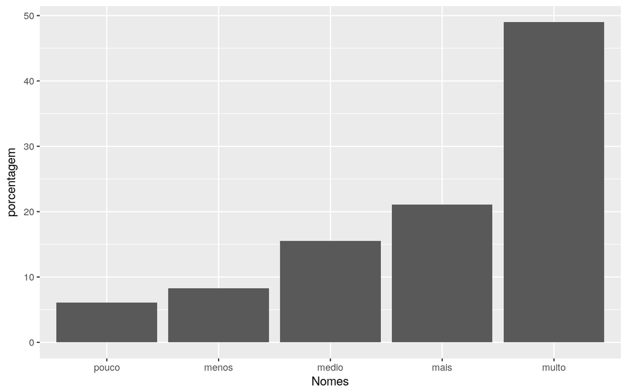

```r
# criar fator com rotulos VER NO CODEBOOK QUAL OS ROTULOS
violenciaData$Nomes <- ''
violenciaData$Nomes <- factor(violenciaData$Var1, levels = c('1', '2', '3', '4', '5'),
labels = c("pouco", "menos", "medio", "mais", "muito"))

# executar grafico
ggplot(data = violenciaData,                # selecionar o banco de dados
       aes(x = Nomes, y = porcentagem) ) +   # selecionar variaveis do eixo x e y
       geom_col()                           # selecionar tipo de gráfico a ser plotado
```

### Gráfico de Frequência

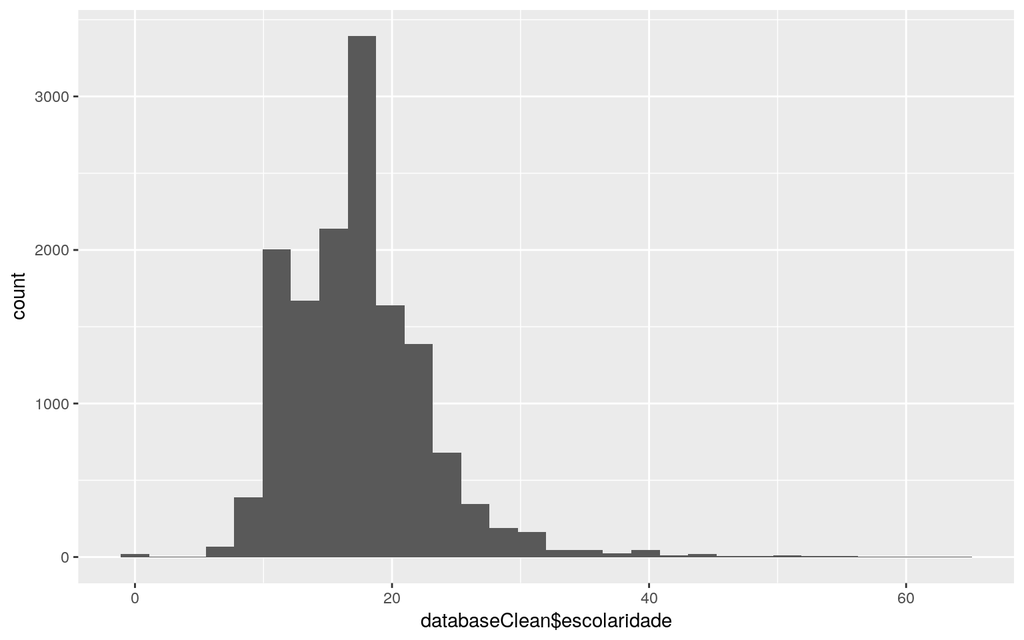

```r
# histograma p/ anos de escolaridade
ggplot(data = databaseClean, aes(x = databaseClean$escolaridade)) + geom_histogram()
```

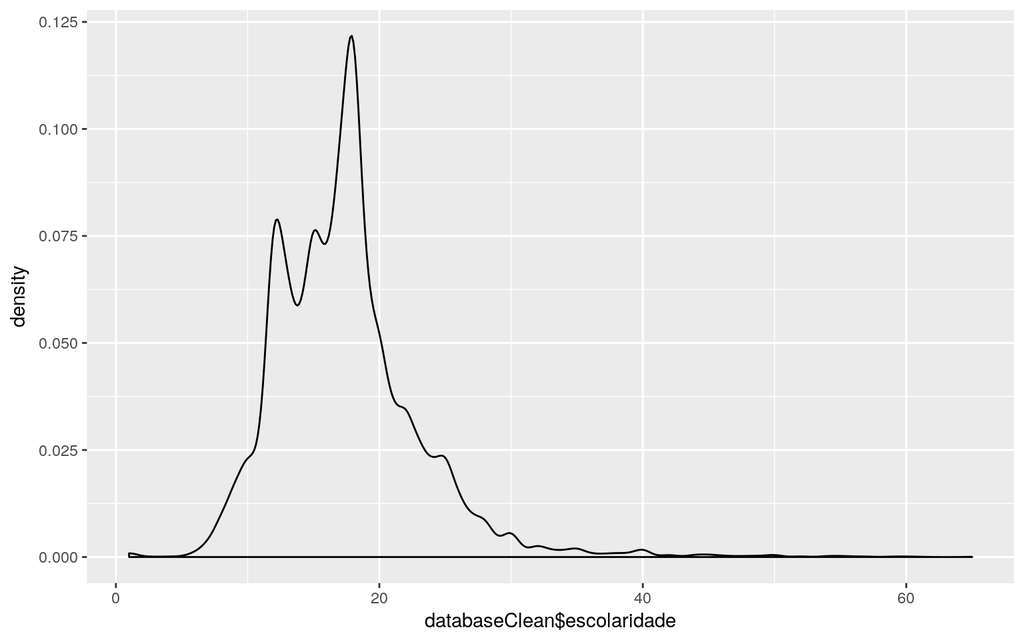

```r
# densidade p/ anos de escolaridade
ggplot(data = databaseClean, aes(x = databaseClean$escolaridade)) + geom_density()
```

Cláudio A. Monteiro

Outubro, 2018